# Rocket League Sideswipe Mystery Items

Toby Hayward

2022-10-30

# Summary

```r
data = read_csv('data/rlssmysteryboxes.csv')
```

A brief investigation to make sure that I wasn’t too asleep when I collected this data.

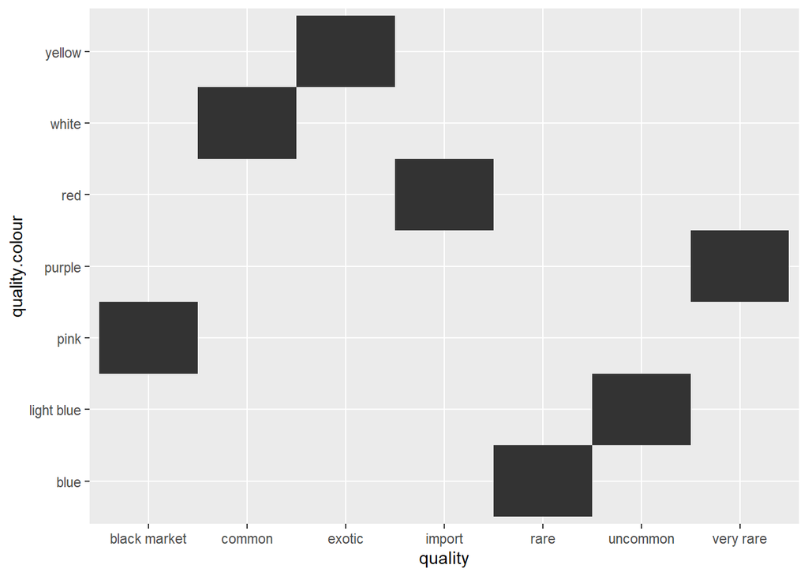

```r
data %>%
  ggplot(aes(x = quality, y = quality.colour)) +
  geom_tile()
```

Okay looks like I got the qualities right every time.

```r
items = data %>%
  group_by(item, quality) %>%
  count() %>%
  pull(item)

items
```

```
##  [1] "artful dodger"      "asterias"           "atomizer"
##  [4] "baseball cap"       "breakout"           "bunny ears"
##  [7] "captain's hat"      "chitchat"           "close one"
## [10] "cloudburst"         "cutter"             "datastream"
## [13] "devastated"         "diestro"            "dominus"
## [16] "donut"              "flames"             "fsl"
## [19] "geometry x"         "gg the clown"       "glhf"
## [22] "heart"              "mariachi hat"       "masato"
## [25] "monkey"             "nemesis"            "nipper"
## [28] "octopus"            "omg"                "on fire"
## [31] "party time"         "pirate's hat"       "pizza"
## [34] "prime cut"          "pro"                "salty"
## [37] "sandwich"           "sharkfin"           "shisa"
## [40] "shockwave"          "shuriken"           "sk8ter"
## [43] "skulls"             "slk"                "spinner"
## [46] "squares"            "stegosaur"          "stripes"
## [49] "sun ray"            "sure striker"       "tachyon"
## [52] "tech"               "tribal"             "triplex"
## [55] "troika"             "turtle"             "wildcat ears"
## [58] "witch hat"          "worried watermelon" "wow"
## [61] "zebra"
```

```r
length(items) / length(unique(items))
```

```
## [1] 1
```

This gives me reason to assume that I didn’t miscategorise any item.  
I’m pretty satisfied with the quality at this point, I’m just going to tidy the data a bit.

```r
data.tidy = data %>%
  mutate(
    # Reorder the qualities. This link https://theglobalgaming.com/rocket-league/rarity-chart#:~:text=Common%3A%20Complete,are%20extremely%20rare.
    quality = factor(toupper(quality), levels = toupper(c('common', 'uncommon', 'rare', 'very rare', 'import', 'exotic', 'black market'))),
    item = toupper(item)
  )

data.tidy
```

```
## # A tibble: 126 × 6
##    box.price item      quality   quality.colour type    item.colour
##        <dbl> <chr>     <fct>     <chr>          <chr>   <chr>
##  1       100 SALTY     VERY RARE purple         banner  <NA>
##  2       200 SLK       RARE      blue           wheel   pink
##  3       300 TRIPLEX   COMMON    white          wheel   <NA>
##  4       400 CLOSE ONE UNCOMMON  light blue     sticker <NA>
##  5       500 GLHF      UNCOMMON  light blue     sticker <NA>
##  6       500 TECH      UNCOMMON  light blue     decal   <NA>
##  7       500 TURTLE    UNCOMMON  light blue     banner  <NA>
##  8       500 ASTERIAS  COMMON    white          wheel   <NA>
##  9       500 PRO       IMPORT    red            decal   pink
## 10       500 GLHF      UNCOMMON  light blue     sticker <NA>
## # … with 116 more rows
```

Now for some questions. The questions I am interested in are:

- What is the expected return on value for a mystery box purchase?
- What are the estimated probabilities of each quality?
- What **item type** is the most frequent?
- How common are **coloured** items?
- What is the distribution of item types for each quality?

Let’s start with the second question since we’ll use it to aid the first: *What is the estimated probablilities of each quality?*

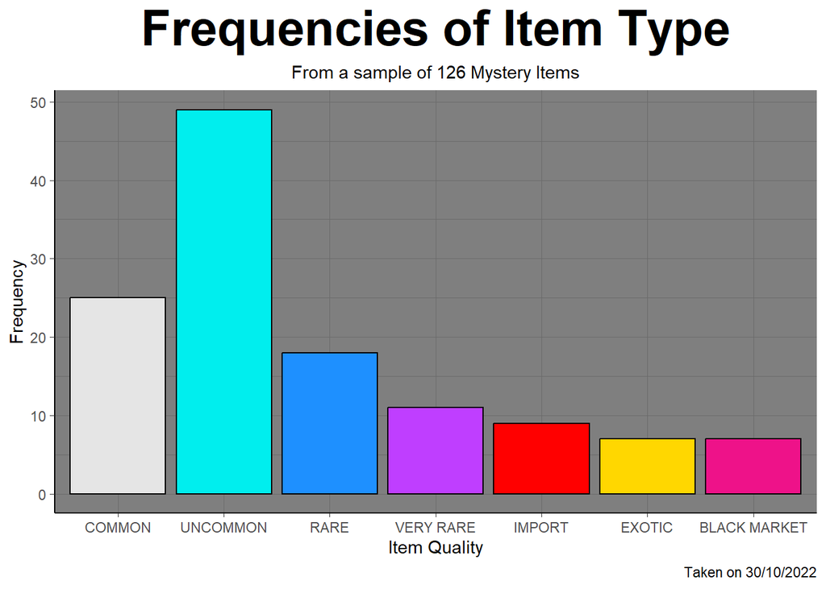

```r
# Get the colours of the qualities
quality.colours = data.tidy %>%
  group_by(quality) %>%
  slice_head() %>%
  # Conveniently in the correct order. It seems like the function did this intentionally judging by the order of box.price.
  pull(quality.colour)


# Those colours are wack. Let's choose nice ones from http://www.stat.columbia.edu/~tzheng/files/Rcolor.pdf

quality.colours.decent = c(
  'grey90', # can't deny it
  'cyan2',
  'dodgerblue',
  'darkorchid1',
  'red',
  'gold',
  'deeppink2'
)

# This is better

data.tidy %>%
  ggplot(aes(x = quality, fill = quality)) +
  geom_bar(col = 'black') +
  scale_fill_manual(values = quality.colours.decent) +
  theme_dark() +
  labs(title = 'Frequencies of Item Type',
       subtitle = paste('From a sample of', nrow(data), 'Mystery Items'),
       caption = 'Taken on 30/10/2022',
       x = 'Item Quality', y = 'Frequency') +
  theme(plot.title = element_text(size = 30, face = 2, hjust = 0.5),
        plot.subtitle = element_text(hjust = 0.5),
        legend.position = 'none',
        axis.line = element_line(colour = 'black'))
```

```r
# Now for the official proportions

frequencies = data.tidy$quality %>% table()
(probabilities.quality = frequencies / sum(frequencies))
```

```
## .
##       COMMON     UNCOMMON         RARE    VERY RARE       IMPORT       EXOTIC
##   0.19841270   0.38888889   0.14285714   0.08730159   0.07142857   0.05555556
## BLACK MARKET
##   0.05555556
```

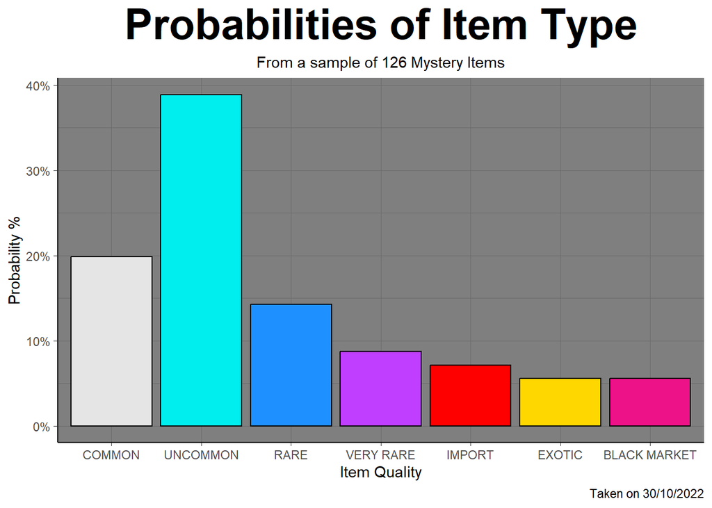

```r
data.tidy %>%
  group_by(quality) %>%
  summarise(p = n() / nrow(data)) %>%
  ggplot(aes(x = quality, fill = quality, y = p * 100)) +
  geom_col(col = 'black') +
  scale_fill_manual(values = quality.colours.decent) +
  theme_dark() +
  labs(title = 'Probabilities of Item Type',
       subtitle = paste('From a sample of', nrow(data), 'Mystery Items'),
       caption = 'Taken on 30/10/2022',
       x = 'Item Quality', y = 'Probability %') +
  theme(plot.title = element_text(size = 30, face = 2, hjust = 0.5),
        plot.subtitle = element_text(hjust = 0.5),
        legend.position = 'none',
        axis.line = element_line(colour = 'black')) +
  scale_y_continuous(breaks = seq(0, 40, 10), labels = c(paste0(seq(0, 40, 10), '%')))
```

Judging by the *current* item shop. It appears that each quality has the following value;

- Common ~ No Value
- Uncommon Topper ~ 400 SP
- Rare Banner ~ 800 SP
- Very Rare Boost ~ 1200 SP
- Import Boost ~ 1800 SP
- Exotic Wheel ~ 2400 SP
- Black Market Car Body ~ 3200 SP

And these videos [1](https://www.youtube.com/watch?v=aIi6ypdDf-E) [2](https://www.youtube.com/watch?v=6gic-dX-EwY).

- Common ~ No Value
- Uncommon Banner ~ 400 SP
- Uncommon Decal ~ 400 SP
- Rare Decal ~ 800 SP
- Rare Title ~ 800 SP
- Very Rare Boost ~ 1200 SP
- Very Rare Wheel ~ 1200 SP
- Import Boost ~ 1800 SP
- Exotic Wheel ~ 2400 SP
- Exotic Car Body ~ 2400 SP
- Black Market Car Body ~ 3200 SP
- Black Market Goal Explosion ~ 3200 SP

Because we can’t let items have no value, let’s just assume that *COMMON* items have **200** SP in value. Hence it seems like the estimated values follow a trend shown below.

```r
data.quality.value = tibble(quality = factor(levels(data.tidy$quality), levels = levels(data.tidy$quality)),
       value = c(200, 400, 800, 1200, 1800, 2400, 3200))
data.quality.value
```

```
## # A tibble: 7 × 2
##   quality      value
##   <fct>        <dbl>
## 1 COMMON         200
## 2 UNCOMMON       400
## 3 RARE           800
## 4 VERY RARE     1200
## 5 IMPORT        1800
## 6 EXOTIC        2400
## 7 BLACK MARKET  3200
```

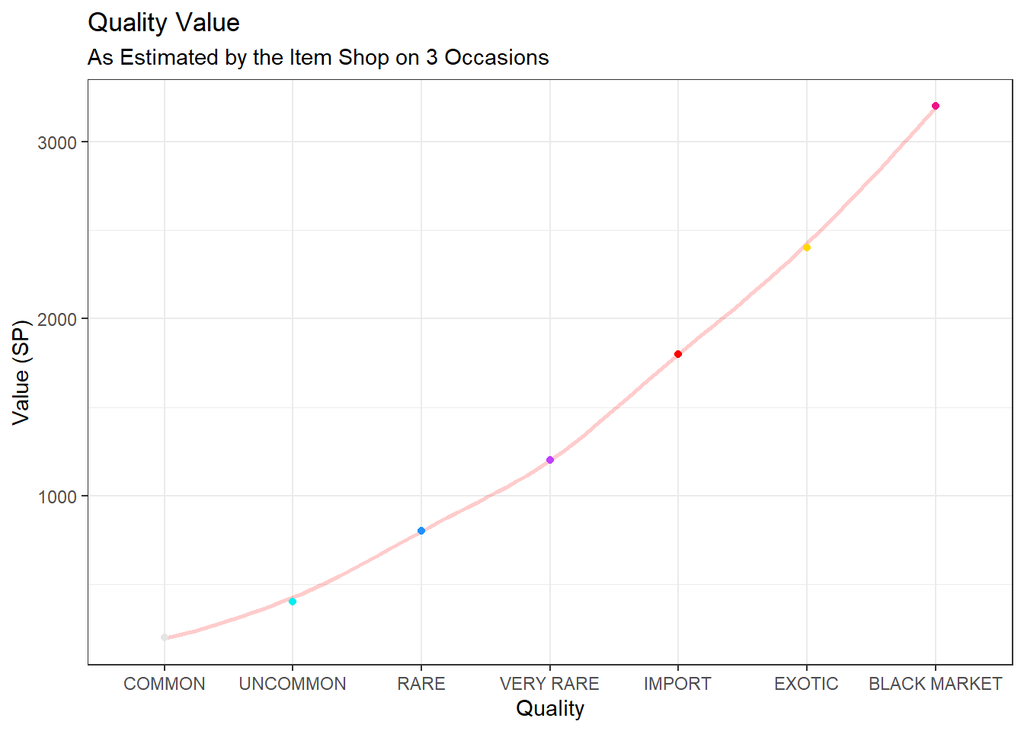

```r
data.quality.value %>%
  ggplot(aes(x = quality, y = value)) +
  geom_point(col = quality.colours.decent) +
  geom_smooth(aes(x = 1:7), col = alpha('red', 0.2), alpha = 0.2, se = F) +
  geom_point(col = quality.colours.decent) +
  theme_bw() +
  labs(title = 'Quality Value',
       subtitle = 'As Estimated by the Item Shop on 3 Occasions',
       x = 'Quality', y = 'Value (SP)')
```

Therefore now we can use this data to answer the question: *What is the expected return on value for a mystery box purchase?*

```r
(data.quality.value.prob = data.quality.value %>%
  left_join(tibble(
    quality = names(probabilities.quality),
    prob = probabilities.quality %>% as.numeric()
  ), by = 'quality') %>%
  mutate(exp_value = value * prob))
```

```
## # A tibble: 7 × 4
##   quality      value   prob exp_value
##   <chr>        <dbl>  <dbl>     <dbl>
## 1 COMMON         200 0.198       39.7
## 2 UNCOMMON       400 0.389      156.
## 3 RARE           800 0.143      114.
## 4 VERY RARE     1200 0.0873     105.
## 5 IMPORT        1800 0.0714     129.
## 6 EXOTIC        2400 0.0556     133.
## 7 BLACK MARKET  3200 0.0556     178.
```

```r
data.quality.value.prob %>%
  pull(exp_value) %>% sum()
```

```
## [1] 853.9683
```

1. Approximate the distribution and calculate it’s probability (Long and boring)
2. Just use the data and assume it’s representative and sufficient (which it very may well be).

```r
(data.tidy2 = data.tidy %>%
  left_join(data.quality.value))
```

```
## # A tibble: 126 × 7
##    box.price item      quality   quality.colour type    item.colour value
##        <dbl> <chr>     <fct>     <chr>          <chr>   <chr>       <dbl>
##  1       100 SALTY     VERY RARE purple         banner  <NA>         1200
##  2       200 SLK       RARE      blue           wheel   pink          800
##  3       300 TRIPLEX   COMMON    white          wheel   <NA>          200
##  4       400 CLOSE ONE UNCOMMON  light blue     sticker <NA>          400
##  5       500 GLHF      UNCOMMON  light blue     sticker <NA>          400
##  6       500 TECH      UNCOMMON  light blue     decal   <NA>          400
##  7       500 TURTLE    UNCOMMON  light blue     banner  <NA>          400
##  8       500 ASTERIAS  COMMON    white          wheel   <NA>          200
##  9       500 PRO       IMPORT    red            decal   pink         1800
## 10       500 GLHF      UNCOMMON  light blue     sticker <NA>          400
## # … with 116 more rows
```

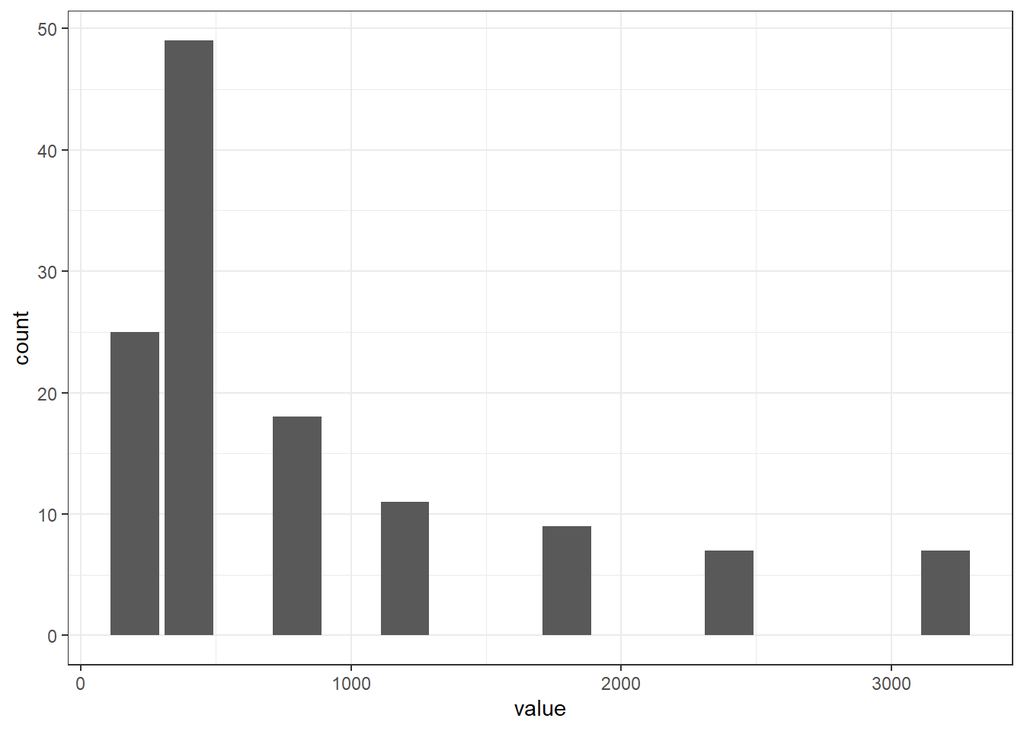

```r
data.tidy2 %>%
  ggplot(aes(x = value)) +
  geom_bar() +
  theme_bw()
```

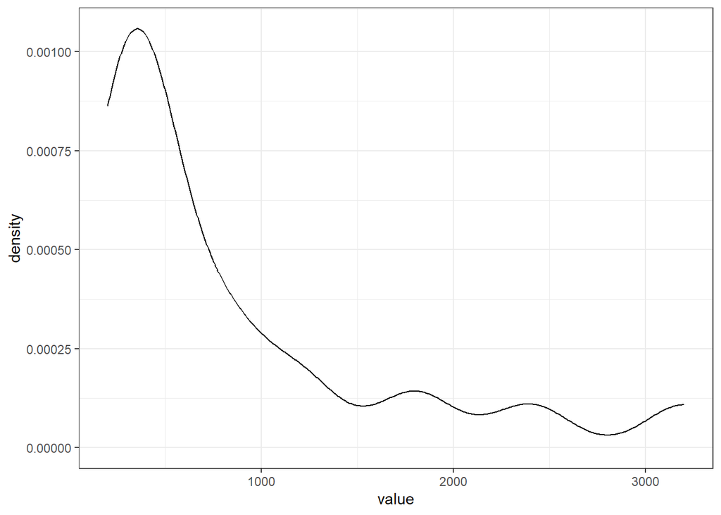

```r
data.tidy2 %>%
  ggplot(aes(x = value)) +
  geom_density() +
  theme_bw()
```

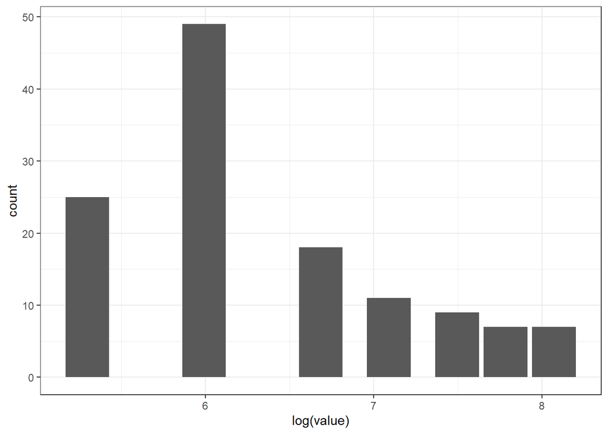

```r
data.tidy2 %>%
  ggplot(aes(x = log(value))) +
  geom_bar() +
  theme_bw()
```

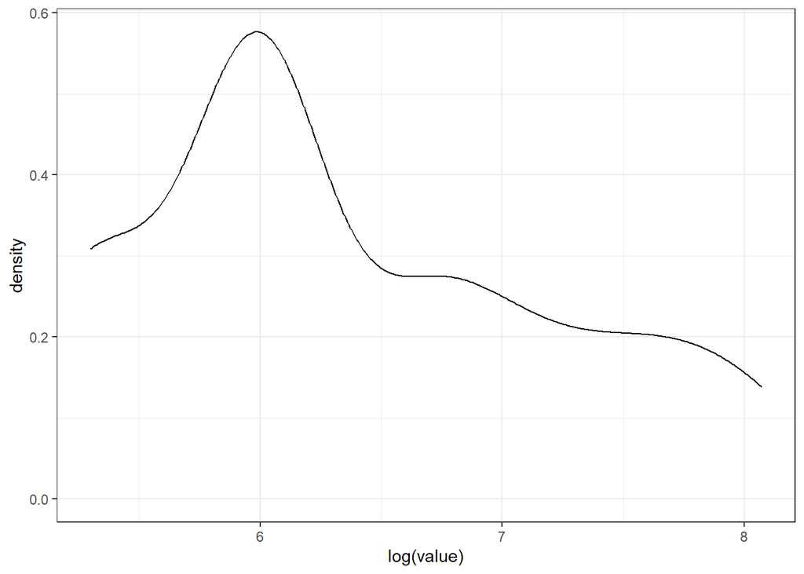

```r
data.tidy2 %>%
  ggplot(aes(x = log(value))) +
  geom_density() +
  theme_bw()
```

This looks like a *Quasi-Poisson* Distribution. We can approximate it’s parameters using *Maximum Likelihood.*  
Because Quasi-Poisson does not have a *Probability-Density-Function*, instead we can transform the data

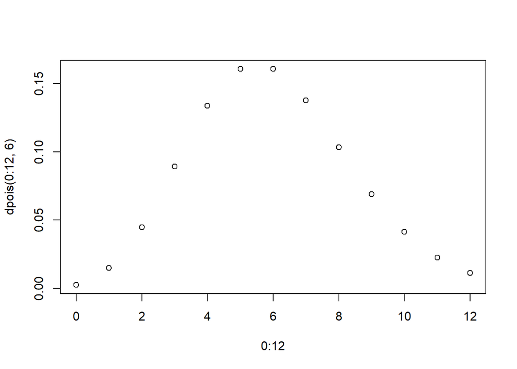

```r
# Screw that! For now...
plot(0:12, dpois(0:12, 6))
```

```r
(probability.profit = (data.tidy2$value[data.tidy2$value > 500] %>% length()) / length(data.tidy2$value))
```

```
## [1] 0.4126984
```

My data claims that if you open a crate, you have a 41.3% chance of getting an item that is worth more than the investment into the crate.